# Lab 2

February 5, 2016

*The object of this lab is to become better aquainted with character data. We will work with a larger set of the earthquake data. This is applicable to public health as trying to learn more about patterns in earthquakes might allow us to determine where they tend to happen and better allow us to prepare for emergencies. We will scrape a number of different data elements from this page to create one large data frome. From there we will practice working with dataframes. Submit your lab as an R Markdown document named* *firstname_lastname_lab1*.

*Each answer must be supported by the code used to find it. Any explanations given must be in complete sentences. If you chose to work with anyone, please list their name as well.*

*You can download the R Markdown file for this lab here:* Lab 2

# Characters, Strings and Data Frames.

We will begin with data from the [Advanced National Seismic System](http://earthquake.usgs.gov/monitoring/anss/). We will use the full data set

- https://drive.google.com/uc?export=download&id=0B8CsRLdwqzbzNG9NS2d4RXZRQ2s
1. Use the `readLines()` function to read this in as a file.

   ```r
     anss <- readLines("https://drive.google.com/uc?export=download&id=0B8CsRLdwqzbzNG9NS2d4RXZRQ2s", warn=FALSE)
   ```

2. How many lines of data are in this?

   ```r
   length(anss)
   ```

   ```
   ## [1] 80315
   ```

3. Use the indexing to find the following (Included in beginning lines of data):
   1. What magnitude of earthquakes are included?

   ```r
   anss[6:7]
   ```

   ```
   ## [1] "<li>minimum_magnitude=5"    "<li>maximum_magnitude=9.99"
   ```

   2. What is the date range for this data?

   ```r
   anss[4:5]
   ```

   ```
   ## [1] "<li>start_time=1898/01/01,00:00:00"
   ## [2] "<li>end_time=2016/02/11,19:15:39"
   ```

4. Use the notes from class and find all of the latitudes and longitudes and save these in a data frame called `lat.long`.

   ```r
       one.geo.coord <- paste("-?[0-9]+\\.[0-9]{4}")
       pair.geo.coords <- paste(rep(one.geo.coord,2),collapse=",")
       have.coords <- grepl(x=anss,pattern=pair.geo.coords)
       coord.matches <- gregexpr(pattern=pair.geo.coords,text=anss[have.coords])
       coords <- regmatches(x=anss[have.coords],m=coord.matches)
       coords <- unlist(coords)
       coord.pairs <- strsplit(coords, ",")
       coord.pairs <- unlist(coord.pairs)
       lat.long <- data.frame(matrix(coord.pairs, ncol=2, byrow=TRUE))
       names(lat.long) <- c("latitude", "longitude")
   ```

5. Find all of the dates and save these in a data frame called `date`.

   ```r
     date <- paste("^[0-9]{4}/[0-9]{2}/[0-9]{2}")
     have.dates <- grep(anss, pattern=date)
     dates.matches <- gregexpr(pattern=date,text=anss[have.dates])
     dates <- regmatches(x=anss[have.dates],m=dates.matches)
     dates <- unlist(dates)
     dates <- as.Date(dates, "%Y/%m/%d")
     date <- data.frame(dates)
   ```

6. Find all of the magnitudes and and save these in a data frame called `magnitude`.

```r
    mag <- paste("[5-9]+\\.[0-9]{2}")
    have.mag <- grep(anss, pattern=mag)
   mag.matches <- gregexpr(pattern=mag, text=anss[have.mag])
    mags <- regmatches(x=anss[have.mag], m=mag.matches)

    mags2 <- rep(NA, length(mags))
    for (i in 1:length(mags) ){
                l <- length(mags[[i]])
                mags2[i] <- mags[[i]][l]
          }

    mags <- unlist(mags2[-1])
    mags <- as.numeric(mags)
    magnitude <- data.frame(mags)
```

7. Find all of the event IDs and save these in a vector called `ids`.

   ```r
     have.id <- grep(anss, pattern="[0-9]{5,12}")
     id.matches <- gregexpr(pattern="[0-9]{5,12}", anss[have.id])
     ids <- regmatches(x=anss[have.id], m=id.matches)
     ids <- unlist(ids)
     ids <- data.frame(ids)
   ```

8. Check the length of 5-7. Do they match the numer of rows in 4? If not which is a problem?

```r
      # Question 4 length
      dim(lat.long)[1]
```

```
## [1] 80300
```

```r
      # Question 5 length
      dim(date)[1]
```

```
## [1] 80300
```

```r
      # Question 6 length
      dim(magnitude)[1]
```

```
## [1] 80300
```

```r
     # Question 7 length
      dim(ids)[1]
```

```
## [1] 79027
```

[output not shown]

*We can see that for question 7 there are less rows. If you go into the original file you can see that event id is missing for a lot of early events.*

9. With there being event names missing we need to create a new way to identify each event.
   1. Find all of the times and save these in a vector called times.

   ```r
     time <- paste("[0-9]:[0-9]{2}:[0-9]{2}\\.[0-9]{2}")
     have.times <- grep(anss, pattern=time)
     times.matches <- gregexpr(pattern=time,text=anss[have.times])
     times <- regmatches(x=anss[have.times],m=times.matches)
     times <- unlist(times)
   ```

   2. Collapse the times into one character with just numbers and no punctuation (i.e. 18:36:00.00 = 18360000).

   ```r
   times <- gsub("[:punc:]" , "", x=times)
   head(times)
   ```

   ```
   ## [1] "83600.00" "63732.70" "33200.00" "02200.00" "44000.00" "72500.00"
   ```

   ```r
   times <- gsub("\\.", "", x=times)
   head(times)
   ```

   ```
   ## [1] "8360000" "6373270" "3320000" "0220000" "4400000" "7250000"
   ```

   3. Collapse all the dates into one character with no punctuation. (i.e. 1898/06/29 = 18980629).

   ```r
   head(dates)
   ```

   ```
   ## [1] "1898-06-29" "1898-10-11" "1899-07-14" "1899-09-04" "1899-09-04"
   ## [6] "1899-09-10"
   ```

   ```r
   dates2 <- gsub("-", "", x=dates)
   head(dates2)
   ```

   ```
   ## [1] "18980629" "18981011" "18990714" "18990904" "18990904" "18990910"
   ```

   4. Join both the new collapsed data and time vectors into one long characer with no spaces.

   ```r
   event.id <- paste(dates2, times, sep="")
   ```

   5. Name the rows of `lat.long` with this new vector. What happens when you try to do this?

   ```r
   rownames(lat.long) <- event.id
   ```

   6. Find the duplicate items and rename them so they are unique.

   ```r
   event.id[duplicated(event.id)]
   ```

   ```
   ## [1] "199706305473948"
   ```

   ```r
   dup <- which(duplicated(event.id))
   dup
   ```

   ```
   ## [1] 49156
   ```

   ```r
   event.id[dup] <- paste(event.id[dup], "a", sep = "")
   which(duplicated(event.id))
   ```

   ```
   ## integer(0)
   ```

   7. Now use the corrected `event.id` vector to name the rows of all the data frames that have been created.

   ```r
   rownames(lat.long) <- event.id
   rownames(magnitude) <- event.id
   rownames(date) <- event.id
   ```

10. Merge this into one large data frame called `earthquakes`.

```r
  earthquakes <- merge(date, lat.long, by="row.names")
  rownames(earthquakes) <- earthquakes[,1]
  earthquakes <- merge(earthquakes[,-1], magnitude, by="row.names")
  rownames(earthquakes) <- earthquakes[,1]
  earthquakes <- earthquakes[,-1]
```

11. How many earthquakes do you have listed?

```r
  dim(earthquakes)[1]
```

```
## [1] 80300
```

12. What is the date of the first eathquake?

```r
min(earthquakes$dates)
```

```
## [1] "1898-06-29"
```

13. What is the date of the earthquake(s) with the largest magnitude.

```r
  max(earthquakes$mags)
```

```
## [1] 9.44
```

```r
  max <- earthquakes[max(earthquakes$mags),]
  max$dates
```

```
## [1] "1899-09-23"
```

14. Generate a new column in `earthquakes` called `mag.cat`. This will be a categorized earthquake.

| Category Name | Magnitude Range |
| --- | --- |
| Moderate | 5-5.99 |
| Strong | 6-6.99 |
| Major | 7-7.99 |
| Great | 8+ |

```r
  earthquakes$mag.cat <- NA
  earthquakes$mag.cat[earthquakes$mags>=5 & earthquakes$mags<6] <- "Moderate"
  earthquakes$mag.cat[earthquakes$mags>=6 & earthquakes$mags<7] <- "Strong"
  earthquakes$mag.cat[earthquakes$mags>=7 & earthquakes$mags<8] <- "Major"
  earthquakes$mag.cat[earthquakes$mags>=8 & earthquakes$mags<10] <- "Great"
```

15. Create a table of earthquakes by magnitude category.

```r
  table(earthquakes$mag.cat)
```

```
##
##    Great    Major Moderate   Strong
##       45      634    74076     5545
```

16. What is the most common type of earthquake? Try and have R give this answer. Meaning have R give you the category name.

```r
  max(table(earthquakes$mag.cat))
```

```
## [1] 74076
```

```r
  which(table(earthquakes$mag.cat)==max(table(earthquakes$mag.cat)))
```

```
## Moderate
##        3
```

```r
  names(which(table(earthquakes$mag.cat)==max(table(earthquakes$mag.cat))))
```

```
## [1] "Moderate"
```

17. Before we try to graph this. What type of data are `latitude` and `longitude` in this data? If its not numeric change it to numeric.

```r
  class(earthquakes$longitude)
```

```
## [1] "factor"
```

```r
  earthquakes$longitude <- as.numeric(as.character(earthquakes$longitude))


  class(earthquakes$latitude)
```

```
## [1] "factor"
```

```r
  earthquakes$latitude <- as.numeric(as.character(earthquakes$latitude))
  head(earthquakes)
```

[output not shown]

18. Create a color coded graph of the earthquakes by magnitude category. Meaning you want the lightest color point to represent a `Moderate` earthquake and the darkest point to represent a `Great` earthquake.

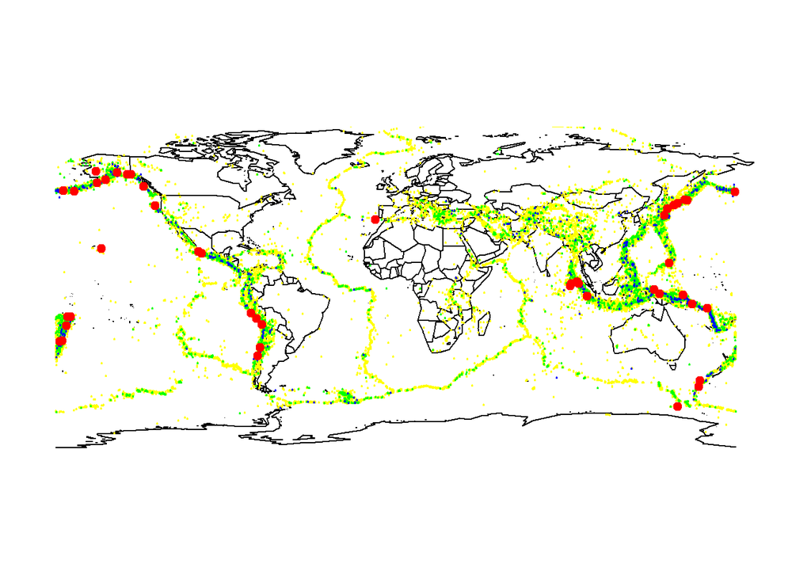

```r
  library(maps)
  map("world")
  earthquakes.mod <- earthquakes[earthquakes$mag.cat=="Moderate",]
  earthquakes.str <- earthquakes[earthquakes$mag.cat=="Strong",]
  earthquakes.maj <- earthquakes[earthquakes$mag.cat=="Major",]
  earthquakes.gre <- earthquakes[earthquakes$mag.cat=="Great",]
  points(x=earthquakes.mod$longitude, y=earthquakes.mod$latitude, pch=19, cex=.2, col="yellow")
  points(x=earthquakes.str$longitude, y=earthquakes.str$latitude, pch=19, cex=.2, col="green")
  points(x=earthquakes.maj$longitude, y=earthquakes.maj$latitude, pch=19, cex=.2, col="blue")
  points(x=earthquakes.gre$longitude, y=earthquakes.gre$latitude, pch=19, col="red")
```

19. Are there any patterns to where the earthquake categories fall?

There are some interesting patterns like down the west coast of north and south america. Most of the `Strong` earthquakes are east of China and North of Australia. There are some Major ones along the Alaskan coast.

20. We will use the `geosphere` package and the most recent maximum earthquake (The data only goes up to 10).
    1. Use the google to learn more about the `distGeo()` function.
       2. Use this function to find the distance of all the earthquakes in relation to this one, place this in a data column called `distance.to.max`.
    2. How many earthquakes are within 1 km of the most recent largest earthquake?
    3. Create a table of earthquakes within 1 km and classify them by magnitude category.
    4. Create a table of earthquakes within 1 km that happened within 10 years of the most recent largest and classify them by magnitude category.
    5. What is the location of the most recent maximum earthquake?

```r
library(geosphere)
#Find most recent Maximum
which(earthquakes$mags ==max(earthquakes$mags))
```

```
## [1] 74320
```

```r
# grab coordinates from this
most.recent <- c(earthquakes[which(earthquakes$mags ==9.44),3], earthquakes[which(earthquakes$mags ==9.44),2])

# Make p1 matrix of this point
p1 <- rep(most.recent, dim(earthquakes)[1])
p1 <- matrix(p1, ncol=2, byrow=TRUE)

# make p2 matrix of other points
p2 <- cbind(earthquakes[,3], earthquakes[,2])

#Use Geosphere to get distance
earthquakes$distance <- distGeo(p1,p2)

#Less than 1km
which(earthquakes$distance<1000)
```

```
## [1] 74320
```

```r
#This yields 74320 but this is the actual recent earthquake so there are none to see how far the next one is we can run:
min(earthquakes$distance[-74320])
```

```
## [1] 1013.502
```

```r
# We can now see that it is 1.01 km away.
```

21. We are at a latitude of 41.824192 and a longidute of -71.406912. How big was the closest earthquake to us? How long ago did this happen.

```r
library(geosphere)

# Coordinates of our point
sph <- c(-71.406912, 41.824192)

# Make p1 matrix of this point
p1 <- rep(sph, dim(earthquakes)[1])
p1 <- matrix(p1, ncol=2, byrow=TRUE)

# make p2 matrix of other points
p2 <- cbind(earthquakes[,3], earthquakes[,2])

#Use Geosphere to get distance
earthquakes$distance.sph <- distGeo(p1,p2)

#Which was closest
closest <- which(earthquakes$distance.sph==min(earthquakes$distance.sph))

#Magnitude of closest
earthquakes$mags[closest]
```

```
## [1] 5.3
```

```r
#Date of closest
earthquakes$dates[closest]
```

```
## [1] "1983-10-07"
```

22. Use (http://www.latlong.net/) to find the latitude and longitude of your hometown. Then find out the closest earthquake to it and how long ago it was.

```r
library(geosphere)

# Coordinates of my old home
home <- c(-79.294886, 42.411187)

# Make p1 matrix of this point
p1 <- rep(home, dim(earthquakes)[1])
p1 <- matrix(p1, ncol=2, byrow=TRUE)

# make p2 matrix of other points
p2 <- cbind(earthquakes[,3], earthquakes[,2])

#Use Geosphere to get distance
earthquakes$distance.sph <- distGeo(p1,p2)

#Which was closest
closest <- which(earthquakes$distance.sph==min(earthquakes$distance.sph))

#date of closest
earthquakes$dates[closest]
```

```
## [1] "1986-01-31"
```

23. Could you scrape all of the data we did in question 4-7 at one time? Show how to do this.

```r
anss2  <- anss[-(1:13)]

strings <- strsplit(anss2, ",")
head(strings)
```

```
## [[1]]
##  [1] "1898/06/29 18:36:00.00" "52.0000"
##  [3] "172.0000"               "0.00"
##  [5] "7.60"                   "ML"
##  [7] "0"                      ""
##  [9] ""                       ""
## [11] "AK"
##
## [[2]]
##  [1] "1898/10/11 16:37:32.70" "50.7100"
##  [3] "-179.5000"              "0.00"
##  [5] "6.90"                   "ML"
##  [7] "0"                      ""
##  [9] ""                       ""
## [11] "AK"
```

[output cut: 32 more lines]

```r
mat.string <- matrix(NA, nrow=length(strings), ncol=5)
for (i in 1:length(strings)){
  mat.string[i,] <- strings[[i]][1:5]
}



data <- as.data.frame(mat.string[-(80301:80302),])

names <- strsplit(anss[13], ",")

names(data)<- names[[1]][1:5]
head(data)
```

```
##                 DateTime Latitude Longitude Depth Magnitude
## 1 1898/06/29 18:36:00.00  52.0000  172.0000  0.00      7.60
## 2 1898/10/11 16:37:32.70  50.7100 -179.5000  0.00      6.90
## 3 1899/07/14 13:32:00.00  60.0000 -150.0000  0.00      7.20
## 4 1899/09/04 00:22:00.00  60.0000 -142.0000 25.00      8.30
## 5 1899/09/04 04:40:00.00  60.0000 -142.0000  0.00      6.90
## 6 1899/09/10 17:25:00.00  60.0000 -140.0000 25.00      7.80
```

```r
data$DateTime <- as.character(data$DateTime)
date.time <- strsplit(data$DateTime, "[[:space:]]")

date <- rep(NA, length(date.time))
for(i in 1:length(date.time)){
  date[i] <- date.time[[i]][1]
}


dates <- as.Date(date, "%Y/%m/%d")

data[,1] <- dates

 names(data[,1]) <- "Date"

 data <- data[,-4]

 head(data)
```

```
##     DateTime Latitude Longitude Magnitude
## 1 1898-06-29  52.0000  172.0000      7.60
## 2 1898-10-11  50.7100 -179.5000      6.90
## 3 1899-07-14  60.0000 -150.0000      7.20
## 4 1899-09-04  60.0000 -142.0000      8.30
## 5 1899-09-04  60.0000 -142.0000      6.90
## 6 1899-09-10  60.0000 -140.0000      7.80
```